# Leaping into Data Wrangling and Basic Analysis with R

Monday, February 29, 2016

## Data Wrangling with dplyr and tidyr

For this workshop we will be discussing the **dplyr** and **tidyr** packages in R.

They are designed to help you to restructure, rearrange, aggregate or transform your data.

There are very nice online tutorials to help learn these packages further:

[dplyr](https://cran.rstudio.com/web/packages/dplyr/vignettes/introduction.html)

[dplyr + tidyr](https://rpubs.com/bradleyboehmke/data_wrangling)

## Getting dplyr and tidyr installed and loaded

```r
#install.packages(c("dplyr","tidyr"))
library(dplyr)
library(tidyr)
```

## Example of using dplyr with baseball data

```r
baseball <- read.csv("http://kmaurer.github.io/documents/baseball.csv")
head(baseball)
```

```
##          id year stint team lg  g  ab  r  h X2b X3b hr rbi sb cs bb so ibb
## 1 ansonca01 1871     1  RC1    25 120 29 39  11   3  0  16  6  2  2  1  NA
## 2 forceda01 1871     1  WS3    32 162 45 45   9   4  0  29  8  0  4  0  NA
## 3 mathebo01 1871     1  FW1    19  89 15 24   3   1  0  10  2  1  2  0  NA
## 4 startjo01 1871     1  NY2    33 161 35 58   5   1  1  34  4  2  3  0  NA
## 5 suttoez01 1871     1  CL1    29 128 35 45   3   7  3  23  3  1  1  0  NA
## 6 whitede01 1871     1  CL1    29 146 40 47   6   5  1  21  2  2  4  1  NA
##   hbp sh sf gidp
## 1  NA NA NA   NA
## 2  NA NA NA   NA
## 3  NA NA NA   NA
## 4  NA NA NA   NA
## 5  NA NA NA   NA
## 6  NA NA NA   NA
```

## Example of using dplyr with baseball data

Leap into RStudio to build script from scratch!

## Your Turn!

- Create a subset of only data from players after 2005
- Create new column for batting average (hits / at bats)
- Calculate the total number of hits for every player over their entire career
- Calculate the record homeruns by one player in a season for each team

## Example of using tidyr with french fry data

```r
data(french_fries, package="reshape2")
head(french_fries)
```

```
##    time treatment subject rep potato buttery grassy rancid painty
## 61    1         1       3   1    2.9     0.0    0.0    0.0    5.5
## 25    1         1       3   2   14.0     0.0    0.0    1.1    0.0
## 62    1         1      10   1   11.0     6.4    0.0    0.0    0.0
## 26    1         1      10   2    9.9     5.9    2.9    2.2    0.0
## 63    1         1      15   1    1.2     0.1    0.0    1.1    5.1
## 27    1         1      15   2    8.8     3.0    3.6    1.5    2.3
```

## Example of using tidyr with french fry data

Leap back over to RStudio to continue this example!

## Visualization with ggplot2

ggplot2 is a visualization package in R that supports many plot types and structures.

Built based on the idea of "the grammar of graphics"

```r
#install.packages(c("ggplot2"))
library(ggplot2)
```

## Example of using ggplot2 with diamonds data

The diamonds data set was included in when you loaded the ggplot2 library

```r
head(diamonds)
```

```
##   carat       cut color clarity depth table price    x    y    z
## 1  0.23     Ideal     E     SI2  61.5    55   326 3.95 3.98 2.43
## 2  0.21   Premium     E     SI1  59.8    61   326 3.89 3.84 2.31
## 3  0.23      Good     E     VS1  56.9    65   327 4.05 4.07 2.31
## 4  0.29   Premium     I     VS2  62.4    58   334 4.20 4.23 2.63
## 5  0.31      Good     J     SI2  63.3    58   335 4.34 4.35 2.75
## 6  0.24 Very Good     J    VVS2  62.8    57   336 3.94 3.96 2.48
```

## ggplot2 with diamonds data

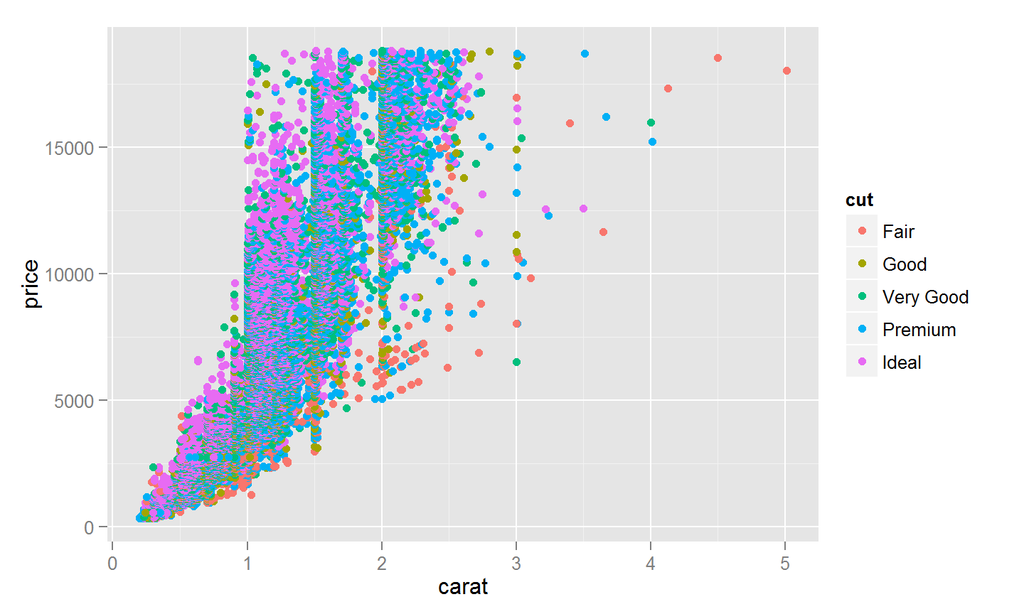

```r
ggplot() +
  geom_point(aes(x=carat,y=price,color=cut), data=diamonds)
```

## ggplot2 with diamonds data

Back to RStudio once again for exploration!